# R Finals

Shai Vaz, Maisa Fraiz

# Introdução

O seguinte projeto é o trabalho final da disciplina de *Introdução ao R Aplicado em Ciência de Dados*, da EPGE.

Utilizaremos dados estatísticos da Secretaria de Segurança Pública do Estado de São Paulo, disponíveis para download em https://basedosdados.org/dataset/br-sp-gov-ssp, e a planilha de informações dos municípios do estado de São Paulo, elaborada pelo IBGE e disponível em https://www.ibge.gov.br/cidades-e-estados/sp/sao-paulo.html. Ambos com acessos em 07/05/2022. Os dois arquivos .csv baixados já estão no repositório GitHub desse projeto, e portanto, tendo-o clonado na sua máquina, não é necessário realizar o download nas fontes.

# Preparação

## Importando os pacotes

```r
# Descomente se você não tiver os pacotes:
# install.packages("tidyverse")
# install.packages("psych")
# devtools::install_github("teunbrand/ggh4x")

library(tidyverse)
library(readxl) #apesar de ser baixado no pacote "tidyverse", precisamos carregar separadamente
library(psych) #usamos para a função describe
library(lubridate) # tambem parte do tidyverse
library(ggh4x)
```

## Importando a base de dados

Lendo duas linhas do arquivo para verificar o formato do CSV (evitando assim erros com o delimitador no momento de salvar os dados, por exemplo)

```r
read_lines("ocorrencias_registradas.csv", n_max = 2)
```

```
[1] "ano,mes,id_municipio,regiao_ssp,homicidio_doloso,numero_de_vitimas_em_homicidio_doloso,homicidio_doloso_por_acidente_de_transito,numero_de_vitimas_em_homicidio_doloso_por_acidente_de_transito,homicidio_culposo_por_acidente_de_transito,homicidio_culposo_outros,tentativa_de_homicidio,lesao_corpor…
[2] "2002,1,3500105,Presidente Prudente,0,0,0,0,0,0,0,0,24,13,2,0,0,0,,,0,,0,0,0,21,0"
```

Já podemos reparar que teremos dados NA na nossa base, porém resolveremos isso mais a diante. Como o separador é vírgula, podemos utilizar o leitor de CSV padrão.

```r
ssp <- read_csv("ocorrencias_registradas.csv")
```

Também utilizaremos a planilha do IBGE com os municípios do estado de São Paulo. Analisando os dados, percebemos que as duas primeiras linhas não contém dados, e após a linha 645, temos metadados e fontes da base. Também reparamos que o símbolo “-” é utilizado para representar NA. Todos esses detalhes foram considerados ao ler o arquivo no projeto.

```r
mun <- read_excel("sp-municipios.xlsx", na="-", skip = 2, n_max = 645)
```

## Primeiras olhadas nos DFs

Vamos verificar se estamos utilizando dataframes do tipo Tibble.

```r
class(ssp)
```

```
[1] "spec_tbl_df" "tbl_df"      "tbl"         "data.frame"
```

```r
class(mun)
```

```
[1] "tbl_df"     "tbl"        "data.frame"
```

### Dataframe principal (SSP)

Vamos qverificar os nomes das colunas e o tipo do dado de cada uma.

```r
spec(ssp)
```

Vamos imprimir os nomes das colunas do dataframe.

```r
names(ssp)
```

```
 [1] "ano"
 [2] "mes"
 [3] "id_municipio"
 [4] "regiao_ssp"
 [5] "homicidio_doloso"
 [6] "numero_de_vitimas_em_homicidio_doloso"
 [7] "homicidio_doloso_por_acidente_de_transito"
 [8] "numero_de_vitimas_em_homicidio_doloso_por_acidente_de_transito"
 [9] "homicidio_culposo_por_acidente_de_transito"
[10] "homicidio_culposo_outros"
[11] "tentativa_de_homicidio"
[12] "lesao_corporal_seguida_de_morte"
[13] "lesao_corporal_dolosa"
[14] "lesao_corporal_culposa_por_acidente_de_transito"
[15] "lesao_corporal_culposa_outras"
[16] "latrocinio"
[17] "numero_de_vitimas_em_latrocinio"
[18] "total_de_estupro"
[19] "estupro"
[20] "estupro_de_vulneravel"
[21] "total_de_roubo_outros"
[22] "roubo_outros"
[23] "roubo_de_veiculo"
[24] "roubo_a_banco"
[25] "roubo_de_carga"
[26] "furto_outros"
[27] "furto_de_veiculo"
```

E olharemos os primeiros 6 registros de nossa tabela.

```r
head(ssp)
```

| ano | mes | id_municipio | regiao_ssp | homicidio_doloso | numero_de_vitimas_em_homicidio_doloso | homicidio_doloso_por_acidente_de_transito | numero_de_vitimas_em_homicidio_doloso_por_acidente_de_transito | homicidio_culposo_por_acidente_de_transito | homicidio_culposo_outros | tentativa_de_homicidio | lesao_corporal_seguida_de_morte | lesao_corporal_dolosa | lesao_corporal_culposa_por_acidente_de_transito | lesao_corporal_culposa_outras | latrocinio | numero_de_vitimas_em_latrocinio | total_de_estupro | estupro | estupro_de_vulneravel | total_de_roubo_outros | roubo_outros | roubo_de_veiculo | roubo_a_banco | roubo_de_carga | furto_outros | furto_de_veiculo |
| --- | --- | --- | --- | --- | --- | --- | --- | --- | --- | --- | --- | --- | --- | --- | --- | --- | --- | --- | --- | --- | --- | --- | --- | --- | --- | --- |
| 2002 | 1 | 3500105 | Presidente Prudente | 0 | 0 | 0 | 0 | 0 | 0 | 0 | 0 | 24 | 13 | 2 | 0 | 0 | 0 | NA | NA | 0 | NA | 0 | 0 | 0 | 21 | 0 |
| 2002 | 2 | 3500105 | Presidente Prudente | 0 | 0 | 0 | 0 | 0 | 0 | 0 | 0 | 24 | 15 | 2 | 0 | 0 | 0 | NA | NA | 0 | NA | 0 | 0 | 0 | 32 | 0 |
| 2002 | 3 | 3500105 | Presidente Prudente | 0 | 0 | 0 | 0 | 0 | 0 | 1 | 0 | 21 | 13 | 5 | 0 | 0 | 0 | NA | NA | 0 | NA | 0 | 0 | 0 | 36 | 0 |
| 2002 | 4 | 3500105 | Presidente Prudente | 0 | 0 | 0 | 0 | 0 | 0 | 1 | 0 | 36 | 13 | 1 | 0 | 0 | 0 | NA | NA | 1 | NA | 0 | 0 | 0 | 45 | 0 |
| 2002 | 5 | 3500105 | Presidente Prudente | 0 | 0 | 0 | 0 | 0 | 0 | 0 | 0 | 27 | 12 | 1 | 0 | 0 | 0 | NA | NA | 1 | NA | 0 | 0 | 0 | 35 | 0 |
| 2002 | 6 | 3500105 | Presidente Prudente | 0 | 0 | 0 | 0 | 0 | 0 | 1 | 0 | 19 | 20 | 3 | 0 | 0 | 0 | NA | NA | 1 | NA | 0 | 0 | 0 | 25 | 0 |

Por fim, daremos uma olhada em dados estatísticos (desvio padrão, média, mediana, mínimo, máximo e outros) de nossas colunas.

```r
describe(ssp)
```

|  | vars | n | mean | sd | median | trimmed | mad | min | max | range | skew | kurtosis | se |
| --- | --- | --- | --- | --- | --- | --- | --- | --- | --- | --- | --- | --- | --- |
| ano | 1 | 153876 | 2011.50 | 5.77 | 2012.0 | 2011.50 | 7.41 | 2002 | 2021 | 19 | 0.00 | -1.21 | 0.01 |
| mes | 2 | 153876 | 6.50 | 3.45 | 6.5 | 6.50 | 4.45 | 1 | 12 | 11 | 0.00 | -1.22 | 0.01 |
| id_municipio | 3 | 153876 | 3528670.39 | 16732.51 | 3528502.0 | 3528633.34 | 21359.82 | 3500105 | 3557303 | 57198 | 0.02 | -1.22 | 42.66 |
| regiao_ssp* | 4 | 153876 | 7.08 | 3.50 | 8.0 | 7.18 | 2.97 | 1 | 12 | 11 | -0.30 | -1.10 | 0.01 |
| homicidio_doloso | 5 | 151296 | 0.67 | 6.78 | 0.0 | 0.11 | 0.00 | 0 | 474 | 474 | 39.03 | 1898.57 | 0.02 |
| numero_de_vitimas_em_homicidio_doloso | 6 | 151296 | 0.71 | 7.21 | 0.0 | 0.11 | 0.00 | 0 | 499 | 499 | 38.59 | 1852.25 | 0.02 |
| homicidio_doloso_por_acidente_de_transito | 7 | 143700 | 0.00 | 0.07 | 0.0 | 0.00 | 0.00 | 0 | 8 | 8 | 33.90 | 2015.26 | 0.00 |
| numero_de_vitimas_em_homicidio_doloso_por_acidente_de_transito | 8 | 143700 | 0.00 | 0.09 | 0.0 | 0.00 | 0.00 | 0 | 11 | 11 | 38.58 | 2502.46 | 0.00 |
| homicidio_culposo_por_acidente_de_transito | 9 | 151296 | 0.54 | 2.36 | 0.0 | 0.20 | 0.00 | 0 | 91 | 91 | 20.12 | 529.17 | 0.01 |
| homicidio_culposo_outros | 10 | 151296 | 0.03 | 0.32 | 0.0 | 0.00 | 0.00 | 0 | 33 | 33 | 36.72 | 2452.02 | 0.00 |

[output cut: 17 more lines]

A análise desses dados estatísticos não faz sentido para todas as varíaveis (por exemplo, não faz sentido calcular a média, desvio padrão, etc, de ano e mês) e, como há muitos dados, para outras faria mais sentido fazer uma investigação anual (é muito mais relevante comparar a média de crimes por ano e se ela está crescendo ou diminuindo do que apenas ver a média do dataset completo). Análises mais complexas serão feitas na seção de Visualização de Dados do projeto.

### Dataframe secundário (MUN)

Seguiremos o mesmo processo para esse dataframe.

```r
names(mun)
```

```
 [1] "Município [-]"
 [2] "Código [-]"
 [3] "Gentílico [-]"
 [4] "Prefeito [2021]"
 [5] "Área Territorial - km² [2021]"
 [6] "População estimada - pessoas [2021]"
 [7] "Densidade demográfica - hab/km² [2010]"
 [8] "Escolarização <span>6 a 14 anos</span> - % [2010]"
 [9] "IDHM <span>Índice de desenvolvimento humano municipal</span> [2010]"
[10] "Mortalidade infantil - óbitos por mil nascidos vivos [2020]"
[11] "Receitas realizadas - R$ (×1000) [2017]"
[12] "Despesas empenhadas - R$ (×1000) [2017]"
[13] "PIB per capita - R$ [2019]"
```

```r
head(mun)
```

| Município [-] | Código [-] | Gentílico [-] | Prefeito [2021] | Área Territorial - km² [2021] | População estimada - pessoas [2021] | Densidade demográfica - hab/km² [2010] | Escolarização <span>6 a 14 anos</span> - % [2010] | IDHM <span>Índice de desenvolvimento humano municipal</span> [2010] | Mortalidade infantil - óbitos por mil nascidos vivos [2020] | Receitas realizadas - R$ (×1000) [2017] | Despesas empenhadas - R$ (×1000) [2017] | PIB per capita - R$ [2019] |
| --- | --- | --- | --- | --- | --- | --- | --- | --- | --- | --- | --- | --- |
| Adamantina | 3500105 | NA | MARCIO CARDIM | 411.987 | 35153 | 82.15 | 97.6 | 0.790 | 2.61 | 160718.68 | 137083.67 | 32400.51 |
| Adolfo | 3500204 | NA | IZAEL ANTONIO FERNANDES | 211.055 | 3545 | 16.85 | 98.6 | 0.730 | NA | 27333.75 | 20103.88 | 31265.58 |
| Aguaí | 3500303 | NA | JOSÉ ALEXANDRE PEREIRA DE ARAÚJO | 474.554 | 36981 | 67.72 | 95.8 | 0.715 | 10.44 | 84094.76 | 72168.73 | 28249.47 |
| Águas da Prata | 3500402 | NA | REGINA HELENA JANIZELO MORAES | 142.673 | 8262 | 53.05 | 98.8 | 0.781 | NA | 29390.25 | 24363.40 | 20835.97 |
| Águas de Lindóia | 3500501 | NA | GILBERTO ABDOU HELOU | 60.126 | 18908 | 287.16 | 96.2 | 0.745 | 4.02 | 86949.22 | 75201.48 | 28385.89 |
| Águas de Santa Bárbara | 3500550 | NA | AROLDO JOSE CAETANO | 404.463 | 6142 | 13.83 | 98.2 | 0.757 | 13.89 | 34484.20 | 28471.95 | 28759.37 |

```r
describe(mun)
```

|  | vars | n | mean | sd | median | trimmed | mad | min | max | range | skew | kurtosis | se |
| --- | --- | --- | --- | --- | --- | --- | --- | --- | --- | --- | --- | --- | --- |
| Município [-]* | 1 | 645 | 323.00 | 186.34 | 323.00 | 323.00 | 238.70 | 1.00 | 645.00 | 644.00 | 0.00 | -1.21 | 7.34 |
| Código [-] | 2 | 645 | 3528697.88 | 16700.33 | 3528700.00 | 3528668.03 | 21210.08 | 3500105.00 | 3557303.00 | 57198.00 | 0.02 | -1.21 | 657.57 |
| Gentílico [-] | 3 | 0 | NaN | NA | NA | NaN | NA | Inf | -Inf | -Inf | NA | NA | NA |
| Prefeito [2021]* | 4 | 645 | 323.00 | 186.34 | 323.00 | 323.00 | 238.70 | 1.00 | 645.00 | 644.00 | 0.00 | -1.21 | 7.34 |
| Área Territorial - km² [2021] | 5 | 645 | 384.84 | 319.93 | 281.03 | 331.31 | 207.03 | 3.61 | 1978.80 | 1975.18 | 1.76 | 3.58 | 12.60 |
| População estimada - pessoas [2021] | 6 | 645 | 72324.24 | 501440.25 | 14297.00 | 25184.95 | 15450.17 | 839.00 | 12396372.00 | 12395533.00 | 23.09 | 562.84 | 19744.19 |
| Densidade demográfica - hab/km² [2010] | 7 | 645 | 301.98 | 1196.74 | 38.87 | 68.12 | 35.80 | 3.73 | 12536.99 | 12533.26 | 7.12 | 56.70 | 47.12 |
| Escolarização 6 a 14 anos - % [2010] | 8 | 645 | 97.94 | 1.34 | 98.10 | 98.05 | 1.04 | 85.30 | 100.00 | 14.70 | -2.82 | 20.76 | 0.05 |
| IDHM Índice de desenvolvimento humano municipal [2010] | 9 | 645 | 0.74 | 0.03 | 0.74 | 0.74 | 0.03 | 0.64 | 0.86 | 0.22 | 0.10 | 0.37 | 0.00 |
| Mortalidade infantil - óbitos por mil nascidos vivos [2020] | 10 | 455 | 13.52 | 10.29 | 10.76 | 12.07 | 5.53 | 1.56 | 142.86 | 141.30 | 5.42 | 56.08 | 0.48 |

[output cut: 3 more lines]

## Limpando os dados

Primeiro, retiramos algumas colunas que consideramos desnecessárias para a nossa análise na tabela mun (Gentílico, Prefeito, Receitas e Despesas)

```r
mun2 <- mun %>%
  select(!c(3,4,11,12))

names(mun2)
```

```
[1] "Município [-]"
[2] "Código [-]"
[3] "Área Territorial - km² [2021]"
[4] "População estimada - pessoas [2021]"
[5] "Densidade demográfica - hab/km² [2010]"
[6] "Escolarização <span>6 a 14 anos</span> - % [2010]"
[7] "IDHM <span>Índice de desenvolvimento humano municipal</span> [2010]"
[8] "Mortalidade infantil - óbitos por mil nascidos vivos [2020]"
[9] "PIB per capita - R$ [2019]"
```

Depois, renomeamos as colunas por questão de simplificação, abreviando os nomes originais. Além disso, a coluna código é alterada para id_município de forma a manter o mesmo nome nos dois DFs, para que seja possível um join.

```r
colnames(mun2) <- c("nome", "id_municipio", "area", "pop", "den", "escol", "idh", "mort_inf", "pib_percap")
names(mun2)
```

```
[1] "nome"         "id_municipio" "area"         "pop"          "den"
[6] "escol"        "idh"          "mort_inf"     "pib_percap"
```

Para o dataset principal, podemos trocar o ID do município pelo seu nome. Mas primeiro, será que temos os mesmos municípios nos dois datasets?

```r
all((unique(ssp$id_municipio)), (mun2$id_municipio))
```

```
[1] TRUE
```

```r
ssp2 <- ssp %>%
  inner_join(mun2[,c("nome","id_municipio")],by = "id_municipio") %>% # faz o inner join
  relocate("nome", .before = "id_municipio") %>% # reposiciona a coluna nome
  select(!id_municipio) %>% # remove a coluna id
  mutate(data = make_date(ano,mes,1),.before=ano) %>% # transforma as colunas mes e ano em uma de data
  filter(data < ymd("2021-09-01")) # remove os registros após 09/2021

head(ssp2)
```

| data | ano | mes | nome | regiao_ssp | homicidio_doloso | numero_de_vitimas_em_homicidio_doloso | homicidio_doloso_por_acidente_de_transito | numero_de_vitimas_em_homicidio_doloso_por_acidente_de_transito | homicidio_culposo_por_acidente_de_transito | homicidio_culposo_outros | tentativa_de_homicidio | lesao_corporal_seguida_de_morte | lesao_corporal_dolosa | lesao_corporal_culposa_por_acidente_de_transito | lesao_corporal_culposa_outras | latrocinio | numero_de_vitimas_em_latrocinio | total_de_estupro | estupro | estupro_de_vulneravel | total_de_roubo_outros | roubo_outros | roubo_de_veiculo | roubo_a_banco | roubo_de_carga | furto_outros | furto_de_veiculo |
| --- | --- | --- | --- | --- | --- | --- | --- | --- | --- | --- | --- | --- | --- | --- | --- | --- | --- | --- | --- | --- | --- | --- | --- | --- | --- | --- | --- |
| 2002-01-01 | 2002 | 1 | Adamantina | Presidente Prudente | 0 | 0 | 0 | 0 | 0 | 0 | 0 | 0 | 24 | 13 | 2 | 0 | 0 | 0 | NA | NA | 0 | NA | 0 | 0 | 0 | 21 | 0 |
| 2002-02-01 | 2002 | 2 | Adamantina | Presidente Prudente | 0 | 0 | 0 | 0 | 0 | 0 | 0 | 0 | 24 | 15 | 2 | 0 | 0 | 0 | NA | NA | 0 | NA | 0 | 0 | 0 | 32 | 0 |
| 2002-03-01 | 2002 | 3 | Adamantina | Presidente Prudente | 0 | 0 | 0 | 0 | 0 | 0 | 1 | 0 | 21 | 13 | 5 | 0 | 0 | 0 | NA | NA | 0 | NA | 0 | 0 | 0 | 36 | 0 |
| 2002-04-01 | 2002 | 4 | Adamantina | Presidente Prudente | 0 | 0 | 0 | 0 | 0 | 0 | 1 | 0 | 36 | 13 | 1 | 0 | 0 | 0 | NA | NA | 1 | NA | 0 | 0 | 0 | 45 | 0 |
| 2002-05-01 | 2002 | 5 | Adamantina | Presidente Prudente | 0 | 0 | 0 | 0 | 0 | 0 | 0 | 0 | 27 | 12 | 1 | 0 | 0 | 0 | NA | NA | 1 | NA | 0 | 0 | 0 | 35 | 0 |
| 2002-06-01 | 2002 | 6 | Adamantina | Presidente Prudente | 0 | 0 | 0 | 0 | 0 | 0 | 1 | 0 | 19 | 20 | 3 | 0 | 0 | 0 | NA | NA | 1 | NA | 0 | 0 | 0 | 25 | 0 |

# Glossário de Variáveis

Agora que já limpamos os dados, podemos fazer um glossário de nossas variáveis.

### Dataframe SSP2

| Variável | Descrição |
| --- | --- |
| data | Ano e mês no formato lubridate, usando 1 como dia padrão |
| nome | Nome do município |
| regiao_ssp | Região definida pela Secretaria de Segurança Pública |
| homicidio_doloso | Homicídio quando se tem a intenção de matar (inclui acidente de trânsito) |
| numero_de_vitimas_em_homicidio_doloso | Vítimas de homicídio doloso (inclui acidente de trânsito) |
| homicidio_doloso_por_acidente_de_transito | Homicídio por acidentes de trânsito com intenção de matar |
| numero_de_vitimas_em_homicidio_doloso_por_acidente_de_transito | Vítimas de homicídio doloso em acidentes de trânsito |
| homicidio_culposo_por_acidente_de_transito | Homicídio por acidentes de trânsito sem intenção de matar |
| homicidio_culposo_outros | Homicídio culposo (exclui acidente de trânsito) |
| tentativa_de_homicidio | Tentativa de homicídio |
| lesao_corporal_seguida_de_morte | Lesão corporal dolosa seguida de homicídio culposo |
| lesao_corporal_dolosa | Lesão corporal dolosa sem resultado em morte |
| lesao_corporal_culposa_por_acidente_de_transito | Lesão corporal sem intenção de ferir ocorrida por acidente de trânsito |
| lesao_corporal_culposa_outras | Lesão corporal sem inteção de ferir (exclui acidente de trânsito) |
| latrocinio | Roubo seguido de morte |
| numero_de_vitimas_em_latrocinio | Vítimas de roubo seguido de morte |
| total_de_estupro | Soma das variáveis de estupro e estupro de vulnerável |
| estupro | Estupro |
| estupro_de_vulneravel | Estupro de vítima vulnerável |
| total_de_roubo_outros | Soma das variáveis roubo_outros, roubo_a_banco e roubo_de_carga |
| roubo_outros | Subtração patrimonial com ameaça ou violência (não inclui veículo, banco ou cargas) |
| roubo_de_veiculo | Roubo de veículos |
| roubo_a_banco | Roubo a banco |
| roubo_de_carga | Roubo de carga |
| furto_outros | Subtração patrimonial sem ameaça ou violência (não inclui veículo) |
| furto_de_veiculo | Furto de veículo |

### Dataframe MUN2

| Variável | Descrição |
| --- | --- |
| nome | Nome do município do estado de São Paulo |
| id_municipio | ID do município no banco de dados do IBGE |
| area | Área territorial em km² em 2021 |
| pop | População estimada em 2021 |
| den | Densidade demográfica em habitantes por km² em 2010 |
| escol | Porcentagem de escolarização em pessoas entre 6 e 14 anos em 2010 |
| idh | IDHM - Índice de desenvolvimento humano municipal em 2010 |
| mort_inf | Mortalidade infantil em óbitos por mil nascidos vivos em 2020 |
| PIB_percap | PIB per capita em reais em 2019 |

# Análise e Visualização de dados

```r
unique(ssp2$regiao_ssp)
```

```
 [1] "Presidente Prudente"                 "Ribeirão Preto"
 [3] "Sorocaba"                            "Araçatuba"
 [5] "Grande São Paulo (exclui a Capital)" "São José do Rio Preto"
 [7] "Bauru"                               "Campinas"
 [9] "Piracicaba"                          "São José dos Campos"
[11] "Santos"                              "Capital"
```

```r
maisPop4 <- mun2 %>%
  arrange(desc(pop)) %>%
  head(4) %>%
  pull(nome)

maisPop4
```

```
[1] "São Paulo"             "Guarulhos"             "Campinas"
[4] "São Bernardo do Campo"
```

## Séries Históricas

Gráfico da taxa de homicídio doloso nas 4 maiores cidades, facetado.

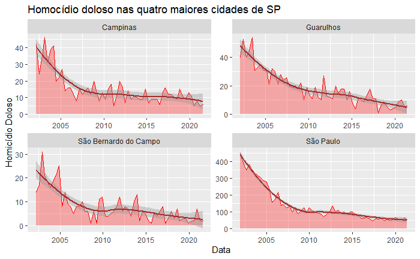

```r
ssp2 %>%
  filter(nome == maisPop4) %>%
  ggplot(aes(x=data,y=homicidio_doloso)) +
  geom_area(color="red", fill="red", alpha=0.3) +
  geom_smooth(color="brown")+
  facet_wrap(vars(nome), scales="free") +
  labs(x = "Data", y = "Homicídio Doloso",
       title = "Homocídio doloso nas quatro maiores cidades de SP")
```

Percebemos uma tendência forte de queda da taxa de homicídios nas maiores cidades do estado quando analisamos a dinâmica de longo prazo.

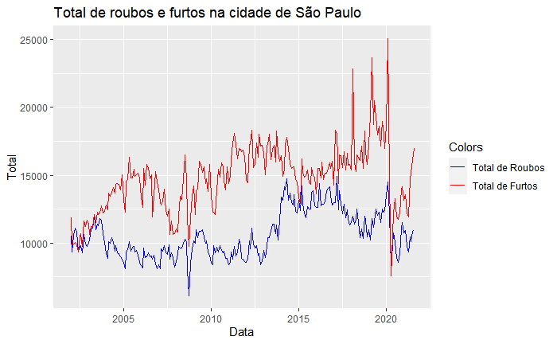

```r
ssp2 %>%
  filter(nome == "São Paulo") %>%
  ggplot(aes(x=data))+
  geom_line(aes(y=total_de_roubo_outros, color = "Total de Roubos"))+
  geom_line(aes(y=furto_outros, color = "Total de Furtos")) +
  labs(x = "Data", y = "Total",
       title = "Total de roubos e furtos na cidade de São Paulo") +
  scale_color_manual(name = "Colors",
                     values = c("Total de Roubos" = "blue", "Total de Furtos" = "red"))
```

Vemos que tanto os roubos (menos numerosos) quanto os furtos (mais numerosos) têm tido uma tendência de crescimento durante a série histórica. Notamos também a queda brusca com o lockdown no início de 2020, com retorno à tendência de crescimentos após alguns meses.

Pensamos na existência de um trade-off entre furto e roubo de veículos, dada a necessidade de uma logística para desmonte, venda de peças, etc. Qual o tipo de crime mais recorrente entre os dois?

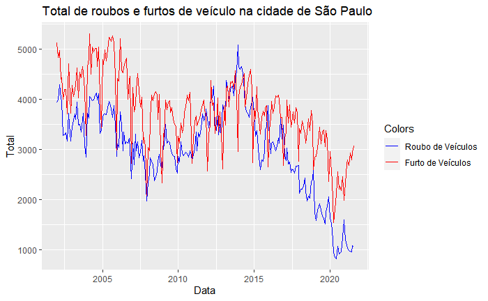

```r
ssp2 %>%
  filter(nome == "São Paulo") %>%
  ggplot(aes(x=data))+
  geom_line(aes(y=roubo_de_veiculo, color = "Roubo de Veículos"))+
  geom_line(aes(y=furto_de_veiculo, color="Furto de Veículos")) +
  labs(x = "Data", y = "Total",
       title = "Total de roubos e furtos de veículo na cidade de São Paulo") +
  scale_color_manual(name = "Colors",
                     values = c("Roubo de Veículos" = "blue", "Furto de Veículos" = "red"))
```

Podemos tentar deixar os dados anualizados, para simplificar os gráficos?

```r
ssp_anual <- ssp2 %>%
  group_by(nome,ano) %>%
  summarise(across(where(is.numeric),sum)) %>%
  select(-mes)
```

Simplificamos o gráfico com as taxas anualizadas.

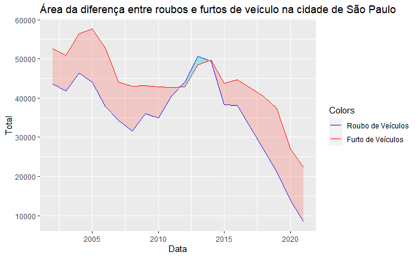

```r
ssp_anual %>%
  filter(nome == "São Paulo") %>%
  ggplot(aes(x=ano))+
  geom_line(aes(y=roubo_de_veiculo, color = "Roubo de Veículos"))+
  geom_line(aes(y=furto_de_veiculo, color="Furto de Veículos")) +
  labs(x = "Data", y = "Total",
       title = "Área da diferença entre roubos e furtos de veículo na cidade de São Paulo") +
  scale_color_manual(name = "Colors",
                     values = c("Roubo de Veículos" = "blue", "Furto de Veículos" = "red")) +
  ggh4x::stat_difference(aes(ymin = roubo_de_veiculo, ymax = furto_de_veiculo), alpha = 0.3, show.legend = FALSE) #da biblioteca ggh4x
```

```r
ssp_taxas2020 <- ssp_anual %>%
  filter(ano == 2020) %>%
  select(furto_outros, homicidio_doloso) %>%
  inner_join(mun2, by = "nome") %>%
  mutate(furto_taxa = furto_outros/pop*100000, homicidio_taxa = homicidio_doloso/pop*100000)
```

## Gráficos de Dispersão

### Furto vs IDH e PIB

Comparando furto e IDH municipal.

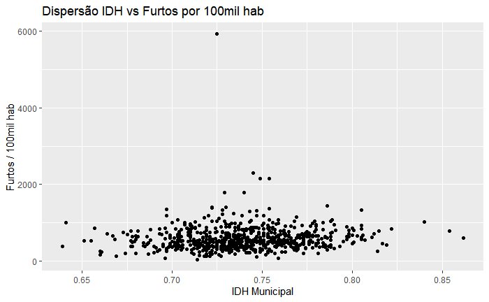

```r
ggplot(ssp_taxas2020, aes(x=idh, y=furto_taxa)) +
    geom_point() +
  labs(x="IDH Municipal", y="Furtos / 100mil hab",
       title = "Dispersão IDH vs Furtos por 100mil hab")
```

Removemos o outlier:

```r
ssp_taxas2020 %>%
  filter(furto_taxa>4000)
```

| nome | furto_outros | homicidio_doloso | id_municipio | area | pop | den | escol | idh | mort_inf | pib_percap | furto_taxa | homicidio_taxa |
| --- | --- | --- | --- | --- | --- | --- | --- | --- | --- | --- | --- | --- |
| Ilha Comprida | 684 | 0 | 3520426 | 196.567 | 11552 | 47.01 | 98.2 | 0.725 | 13.79 | 93630.19 | 5921.053 | 0 |

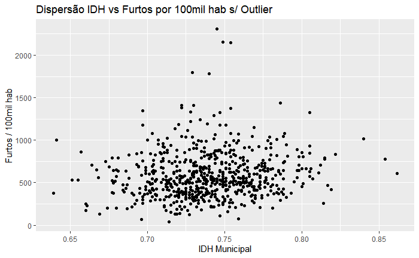

```r
ssp_taxas2020 %>%
  filter(nome != "Ilha Comprida") %>%
  ggplot(aes(x=idh, y=furto_taxa)) +
    geom_point() +
  labs(x="IDH Municipal", y="Furtos / 100mil hab",
       title = "Dispersão IDH vs Furtos por 100mil hab s/ Outlier")
```

Comparamos furto contra PIB per capita.

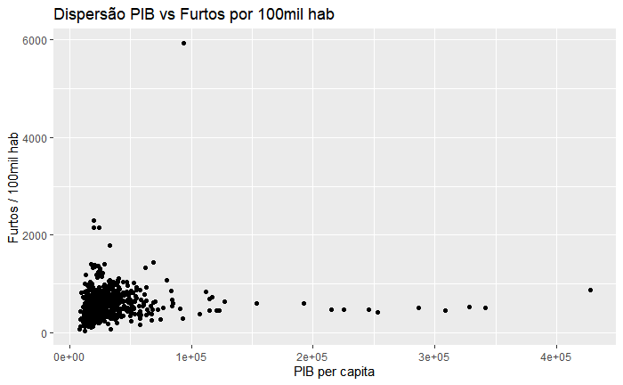

```r
ggplot(ssp_taxas2020, aes(x=pib_percap, y=furto_taxa)) +
    geom_point() +
  labs(x="PIB per capita", y="Furtos / 100mil hab",
       title = "Dispersão PIB vs Furtos por 100mil hab")
```

Retiramos outliers.

[figure not shown]

```r
ssp_taxas2020 %>%
  filter(pib_percap < 1.5*10^5 & furto_taxa <4000) %>%
  ggplot(aes(x=pib_percap, y=furto_taxa)) +
    geom_point() +
  labs(x="PIB per capita", y="Furtos / 100mil hab",
       title = "Dispersão IDH vs Furtos por 100mil hab s/ Outliers")
```

### Homicídio vs IDH e PIB

Homicídio doloso contra IDH.

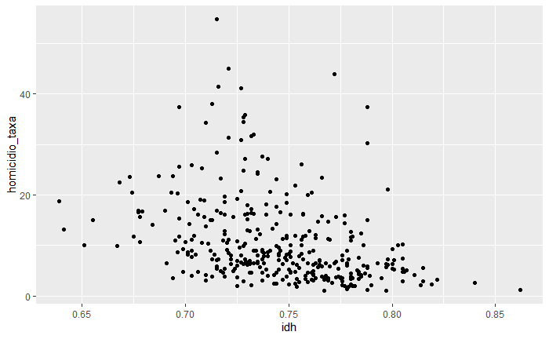

```r
ssp_taxas2020 %>%
  filter(homicidio_doloso > 0) %>% #apenas os valores positivos
  ggplot(aes(x=idh, y=homicidio_taxa)) +
    geom_point()
```

Homicídio doloso contra PIB per capita.

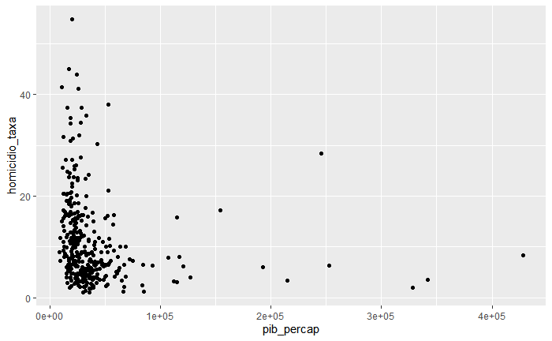

```r
ssp_taxas2020 %>%
  filter(homicidio_taxa > 0) %>%
  ggplot(aes(x=pib_percap, y=homicidio_taxa)) +
  geom_point()
```

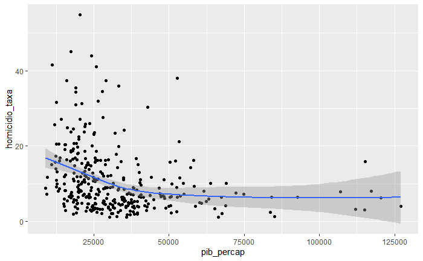

```r
ssp_taxas2020 %>%
  filter(pib_percap < 1.5*10^5 & homicidio_taxa > 0) %>%
  ggplot(aes(x=pib_percap, y=homicidio_taxa)) +
  geom_point() +
  geom_smooth(method = "gam")
```

# Referências

### Fontes de tecnicas de programação em R

- https://github.com/swirldev/swirl_courses/tree/master/R_Programming. Acessos durante o semestre.
- https://github.com/sysilviakim/swirl-tidy , acessos durante o semestre.
- Wickhan & Grolemund, **R for Data Science**. Disponível em https://r4ds.had.co.nz/. Acessos durante o semestre.
- Cheat Sheets Rstudio https://www.rstudio.com/resources/cheatsheets/. Utilizamos as de Ggplot2, Dplyr, Lubridate e RMarkdown.
- Aprendendo a usar Rstudio aliado ao Github https://happygitwithr.com/index.html. Acesso em 30/05/2022.

### Fontes específicas de código

- Legendas para múltiplos geom_line https://stackoverflow.com/questions/34379268/ggplot-and-two-different-geom-line-the-legend-does-not-appear acesso em 13/06/2022
- Scatterplot https://r-graph-gallery.com/272-basic-scatterplot-with-ggplot2.html acesso em 13/06/2022
- Time series with conditional area fill https://r-graph-gallery.com/web-time-series-and-facetting.html. Acesso 13/06/2022.
- Soma de varáveis por grupo (uso do helper “where”) com dplyr https://stackoverflow.com/questions/1660124/how-to-sum-a-variable-by-group. Acesso em 12/06/2022.
- Uso de faceting https://r-graph-gallery.com/223-faceting-with-ggplot2.html. Acesso em 06/06/2022.
- Uso de joins https://rpubs.com/odenipinedo/joining-data-with-dplyr. Acesso em 06/06/2022.
- Uso da função psych::describe https://www.rdocumentation.org/packages/psych/versions/1.0-17/topics/describe acesso em 06/06/2022.